# Module 1: Welcome to R

## University of North Carolina Wilmington

# Familiarizing Yourself with RStudio

In this document you will learn the basic set up and language used in RStudio. This document will familiarize you with the interface so you can easily work through these modules. The most important step is to install R and RStudio. If you haven't done so, follow this link:

https://www.r-project.org/

## Opening RStudio

When you first open RStudio you will be presented with four quadrants on your screen.

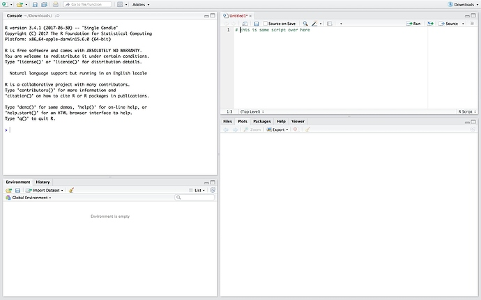

**Files**

This shows you all files the are available to you as a user of R. This is another way you can import data and set your working directory.

**Plots**

The plots tab shows you all of the graphs or plots you have generated using your code. You can select the arrows to shift back and forth between each graph. You can also export and save your graph using this tab.

**Packages**

The packages tab allows you to install, activate, and update certain packages. Packages allow you to run certain functions. The list shows you all of the packages that you have installed, and clicking the check mark activates the package. If you need to install a new package you can hit the install button on the top left corner. There you can search for the package you need and install it. You will need to activate each package you need during each R session and prior to running the subsequent function.

**Help**

The help tab allows you to search for a particular code, term, concept, or any other help directly from the RStudio app.

**Viewer**

In the Viewer tab you can view local web content.

# R Language

## Data Structures

Now that you are familiar with the set up of R, it is important to learn the vocabulary the comes along with the interface. Next module I will introduce the code needed to create these objects in Rstudio.

**Vector**

A vector is a data structure. It contains elements of the same type in a sequence.

```
{r}
vector<-c(1,2,3,4,5,6)
```

As you can see, this vector is numeric. Vectors could be any type of variable as long as each data point is the same type.

**Matrices**

A matrix is another type of data structure in R. It can be a combination of two or more vectors and has two dimensions: rows and columns. A matrix looks like this:

```
{r}
matrix<- matrix(vector, nrow = 3, ncol=2, byrow=TRUE)
```

**Lists**

A list is a data structure that contains different types of elements. For example you could have numeric and nominal variables.

```
{r}
list<-list("List 1"=1,2,3, "List 2"="a", "b", "c")
```

**Array**

An array is similar to a matrix but has a third dimension. It is essentially a bunch of stacked matrices.

```
{r}
vector<-c(1,2,3,4,5,6)
vector2<-c(7,8,9,10,11,12)
Array<-array(c(vector, vector2), dim=c(4,4,3))
```

## Variable Types

**Character**

A character variable is a letter or string of letters.

**Numeric**

Any variable that is a number.

**Integer**

Any numeric variable that can only be a whole number (no decimals).

**Logical**

Variables that can only be true or false. They typically indicate if a condition is true or false.

**Complex**

These variables involve a numeric variable with an the imaginary value "i".

# Summary

## Data Structures

The table below summarizes the data structures often used in R.

| Dimension | Homogeneous | Heterogeneous |
| --- | --- | --- |
| One | Atomic Vector | List |
| Two | Matrix | Data Frame |
| Three | Array |  |

Homogeneous means that the variable type must be the same type for each variable, whereas heterogeneous means that the data structure can contain multiple different types of data.

## Variable Types

The table below summarizes variable types often used in R.

| Variable Type | Example |  |
| --- | --- | --- |
| Character | "A", "B", "C" |  |
| Numeric | 1, 2.5, 3 |  |
| Integer | 10, 20 ,30 |  |
| Logical | True, False |  |
| Complex | 4+6i |  |

# Practice!

Make each of the data structure types using your own numbers. Copy and paste the code below into your own R session and analyze the output.

```
{r}
Practice_vector<-c()
Practice_matrix<-matrix()
Practice_list<-list()
Practice_array<-array()
```

Now run the following code to see the output for each data type. This will show you what each data structure type looks like.

```
{r}
print(Practice_vector)
print(Practice_matrix)
print(Practice_list)
print(Practice_array)
```